# Bayesian GLMM Part1

- intervals: plots the observed data overlayed ontop of posterior predictions associated with each level of the predictor. Ideally, the observed data should all fall within the predictive intervals.

```
Using all posterior draws for ppc type 'intervals' by default.
```

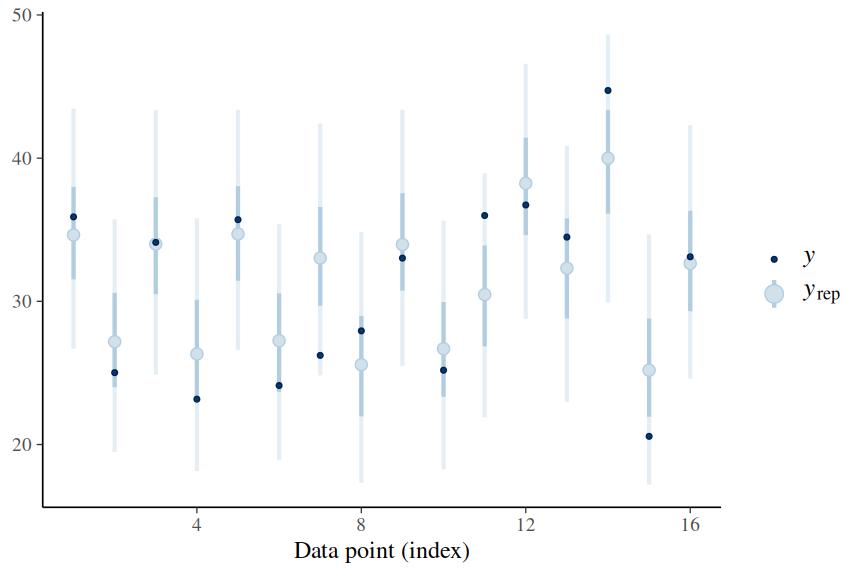

```r
tobacco_brm3 |> pp_check(group = "TREATMENT", type = "intervals")
```

```
Using all posterior draws for ppc type 'intervals_grouped' by default.
```

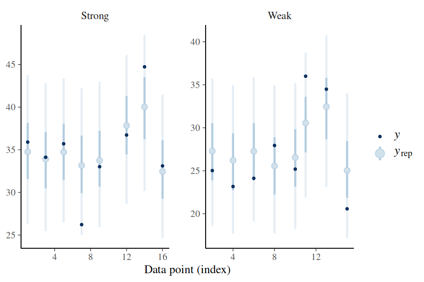

```r
tobacco_brm3 |> pp_check(group = "TREATMENT", type = "intervals_grouped")
```

```
Using all posterior draws for ppc type 'violin_grouped' by default.
```

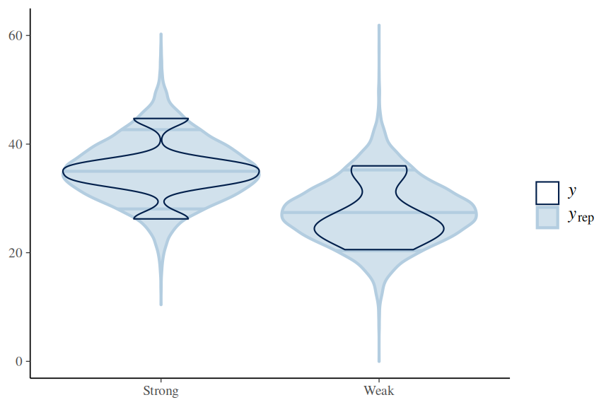

```r
tobacco_brm3 |> pp_check(group = "TREATMENT", type = "violin_grouped")
```

The `shinystan` package allows the full suite of MCMC diagnostics and posterior predictive checks to be accessed via a web interface.

```r
# library(shinystan)
# launch_shinystan(tobacco_brm2)
```

**DHARMa residuals**

DHARMa residuals provide very useful diagnostics. Unfortunately, we cannot directly use the `simulateResiduals()` function to generate the simulated residuals. However, if we are willing to calculate some of the components ourself, we can still obtain the simulated residuals from the fitted stan model.

We need to supply:

- simulated (predicted) responses associated with each observation.
- observed values
- fitted (predicted) responses (averaged) associated with each observation

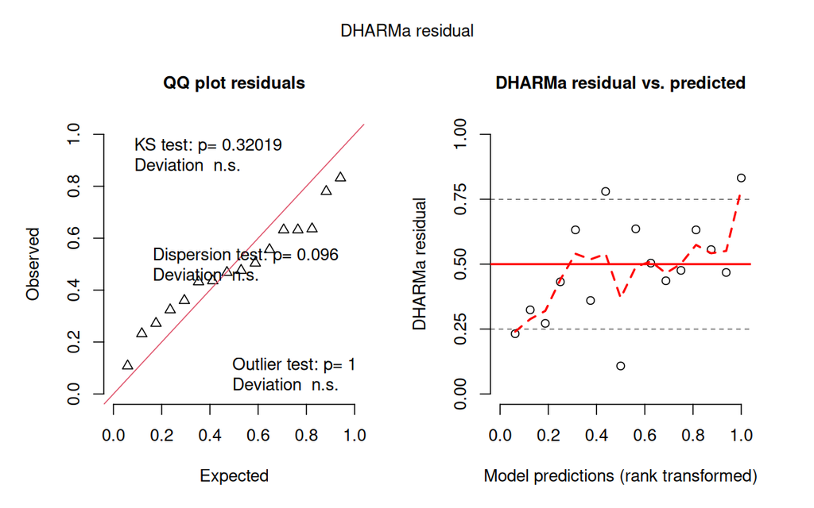

```r
preds <- tobacco_brm4 |> posterior_predict(ndraws = 250, summary = FALSE)
tobacco_resids <- createDHARMa(
  simulatedResponse = t(preds),
  observedResponse = tobacco$NUMBER,
  fittedPredictedResponse = apply(preds, 2, median),
  integerResponse = FALSE
)
plot(tobacco_resids, quantreg = FALSE)
```

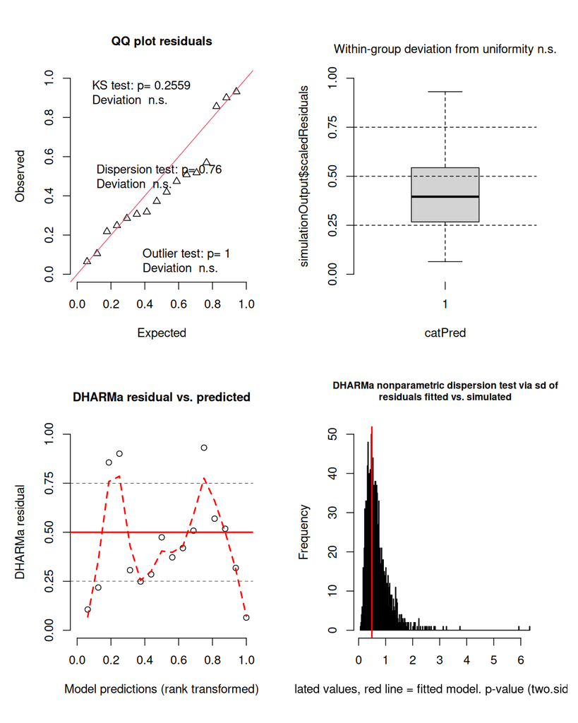

```r
tobacco_resids <- make_brms_dharma_res(tobacco_brm3, integerResponse = FALSE)
wrap_elements(~ testUniformity(tobacco_resids)) +
  wrap_elements(~ plotResiduals(tobacco_resids, form = factor(rep(1, nrow(tobacco))))) +
  wrap_elements(~ plotResiduals(tobacco_resids, quantreg = FALSE)) +
  wrap_elements(~ testDispersion(tobacco_resids))
```

**Conclusions:**

- the simulated residuals do not suggest any issues with the residuals
- there is no evidence of a lack of fit.

# 7 Partial effects plots

**brms**

**conditional_effects**

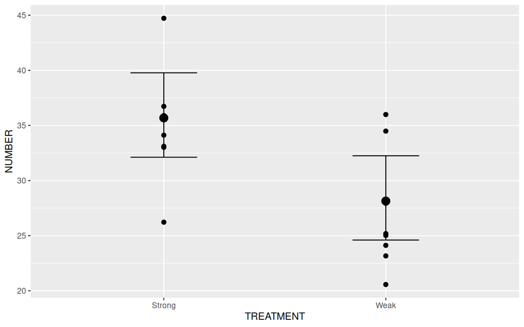

```r
tobacco_brm3 |>
  conditional_effects() |>
  plot(points = TRUE)
```

**ggpredict**

```
Note: uncertainty of error terms are not taken into account. Consider
  setting `interval` to "prediction". This will call `posterior_predict()`
  instead of `posterior_epred()`.
```

```
Data points may overlap. Use the `jitter` argument to add some amount of
  random variation to the location of data points and avoid overplotting.
```

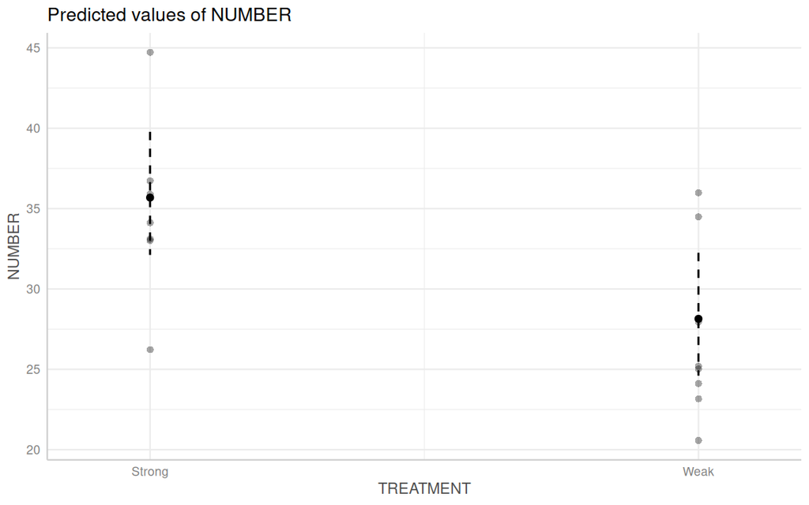

```r
tobacco_brm3 |>
  ggpredict() |>
  plot(show_data = TRUE)
```

**ggemmeans**

```
Data points may overlap. Use the `jitter` argument to add some amount of
  random variation to the location of data points and avoid overplotting.
```

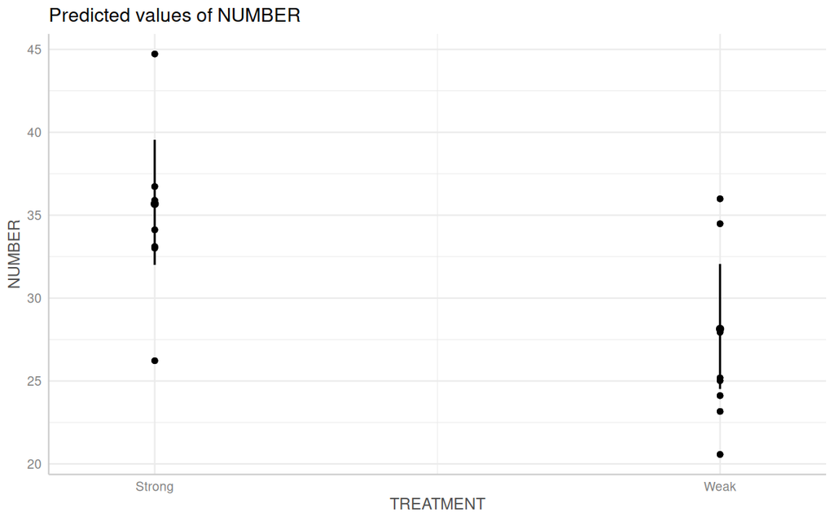

```r
tobacco_brm3 |>
  ggemmeans(~TREATMENT) |>
  plot(show_data = TRUE) +
  geom_point(data = tobacco, aes(y = NUMBER, x = as.numeric(TREATMENT)))
```

**fitted_draws**

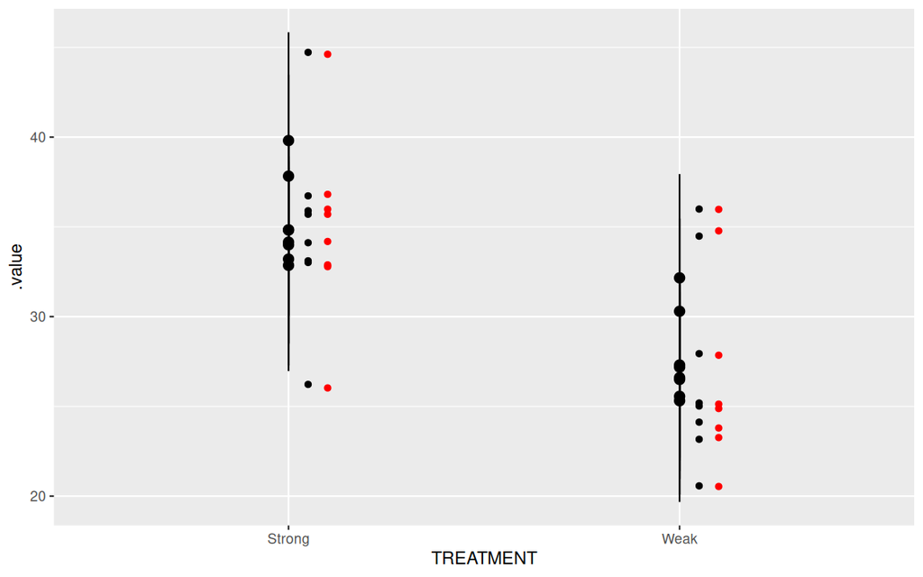

```r
Partial.obs <- tobacco_brm3$data |>
  mutate(
    Pred = predict(tobacco_brm3)[, "Estimate"],
    Resid = resid(tobacco_brm3)[, "Estimate"],
    Obs = Pred + Resid
  )

tobacco_brm3 |>
  fitted_draws(newdata = tobacco) |>
  median_hdci() |>
  ggplot(aes(x = TREATMENT, y = .value)) +
  geom_pointrange(aes(ymin = .lower, ymax = .upper)) +
  geom_line() +
  geom_point(
    data = Partial.obs, aes(y = Obs, x = TREATMENT), color = "red",
    position = position_nudge(x = 0.1)
  ) +
  geom_point(
    data = tobacco, aes(y = NUMBER, x = TREATMENT),
    position = position_nudge(x = 0.05)
  )
```

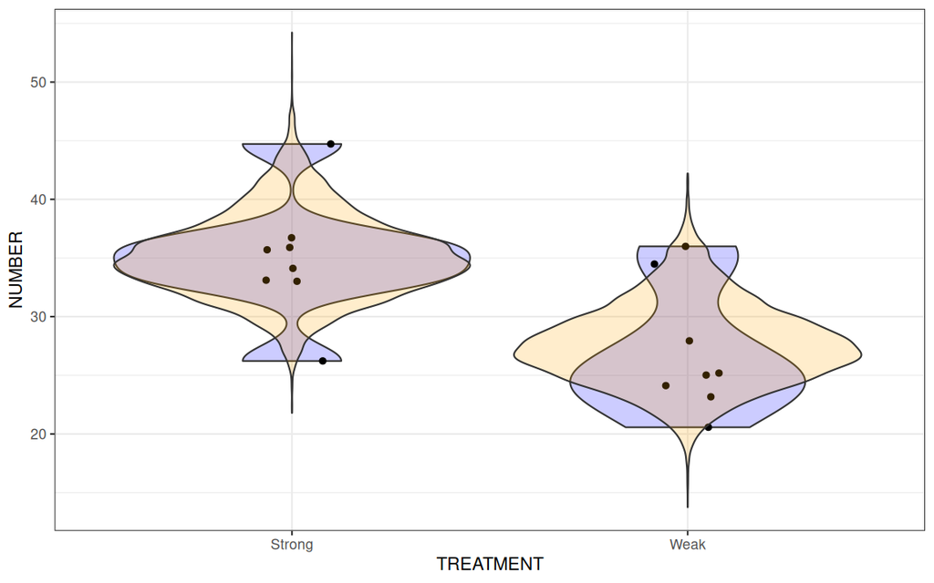

```r
tobacco_brm3 |>
  epred_draws(newdata = tobacco) |>
  ggplot() +
  geom_violin(data = tobacco, aes(y = NUMBER, x = TREATMENT), fill = "blue", alpha = 0.2) +
  geom_point(
    data = tobacco, aes(y = NUMBER, x = TREATMENT),
    position = position_jitter(width = 0.1, height = 0)
  ) +
  geom_violin(aes(y = .epred, x = TREATMENT), fill = "orange", alpha = 0.2) +
  theme_bw()
```

# 8 Model investigation

**brms**

**summary**

```r
tobacco_brm3 |> summary()
```

```
 Family: gaussian
  Links: mu = identity; sigma = identity
Formula: NUMBER ~ (1 | LEAF) + TREATMENT
   Data: tobacco (Number of observations: 16)
  Draws: 3 chains, each with iter = 5000; warmup = 2500; thin = 5;
         total post-warmup draws = 1500

Multilevel Hyperparameters:
~LEAF (Number of levels: 8)
              Estimate Est.Error l-95% CI u-95% CI Rhat Bulk_ESS Tail_ESS
sd(Intercept)     3.53      1.90     0.27     7.61 1.00      947     1250

Regression Coefficients:
              Estimate Est.Error l-95% CI u-95% CI Rhat Bulk_ESS Tail_ESS
Intercept        35.73      1.87    32.12    39.78 1.00     1473     1457
TREATMENTWeak    -7.52      2.20   -11.73    -2.98 1.00     1244     1385

Further Distributional Parameters:
      Estimate Est.Error l-95% CI u-95% CI Rhat Bulk_ESS Tail_ESS
sigma     4.40      1.15     2.61     7.10 1.00     1207     1312

Draws were sampled using sampling(NUTS). For each parameter, Bulk_ESS
and Tail_ESS are effective sample size measures, and Rhat is the potential
scale reduction factor on split chains (at convergence, Rhat = 1).
```

**Conclusions:**

- the intercept indicates that the Strong treatment has an average of 35.73 lesions.
- the Weak treatment has 7.52 fewer lesions.
- the variance in intercepts across all Leaves is 3.53
- the scale of variance between Leaves is very similar to the variance within Leaves (sigma, 4.4).

**summarise_draws**

```r
tobacco_brm3 |>
  summarise_draws(
    median,
    ~ HDInterval::hdi(.x),
    N = ~ length(.x),
    Pl = ~ mean(.x < 0),
    Pg = ~ mean(.x > 0),
    rhat,
    ess_bulk,
    ess_tail
  )
```

```
# A tibble: 19 × 10
   variable    median    lower  upper     N     Pl    Pg  rhat ess_bulk ess_tail
   <chr>        <dbl>    <dbl>  <dbl> <dbl>  <dbl> <dbl> <dbl>    <dbl>    <dbl>
 1 b_Interce…  35.7    3.20e+1  39.5   1500 0      1     1.00     1473.    1457.
 2 b_TREATME…  -7.58  -1.15e+1  -2.86  1500 0.998  0.002 1.00     1244.    1385.
 3 sd_LEAF__…   3.45   5.68e-3   6.87  1500 0      1     1.00      947.    1250.
 4 sigma        4.26   2.39e+0   6.61  1500 0      1     0.999    1207.    1312.
 5 Intercept   31.9    2.90e+1  35.2   1500 0      1     1.00     1475.    1290.
 6 r_LEAF[L1…  -0.631 -5.21e+0   4.30  1500 0.638  0.362 0.998    1525.    1543.
 7 r_LEAF[L2…  -1.48  -7.33e+0   2.68  1500 0.753  0.247 1.00     1335.    1321.
 8 r_LEAF[L3…  -0.619 -5.92e+0   3.54  1500 0.653  0.347 1.00     1445.    1457.
 9 r_LEAF[L4…  -2.29  -8.18e+0   2.12  1500 0.82   0.18  1.00     1367.    1312.
10 r_LEAF[L5…  -1.31  -7.00e+0   2.98  1500 0.739  0.261 1.00     1131.    1393.
11 r_LEAF[L6…   1.87  -1.99e+0   7.54  1500 0.187  0.813 1.00     1336.    1538.
12 r_LEAF[L7…   3.91  -7.27e-1   9.60  1500 0.0767 0.923 0.999    1256.    1458.
13 r_LEAF[L8…  -2.55  -8.36e+0   2.05  1500 0.855  0.145 1.00     1221.    1384.
14 prior_Int…  34.9    2.89e+1  40.7   1500 0      1     1.000    1583.    1497.
15 prior_b      0.205 -1.99e+1  20.5   1500 0.493  0.507 1.000    1474.    1403.
16 prior_sig…   3.77   1.19e-2  15.4   1500 0      1     1.01     1550.    1338.
17 prior_sd_…   3.89   2.36e-4  14.5   1500 0      1     0.999    1485.    1501.
18 lprior     -10.8   -1.20e+1  -9.88  1500 1      0     1.000    1544.    1499.
19 lp__       -64.8   -7.30e+1 -58.2   1500 1      0     1.00      883.    1269.
```

```r
## or if you want to exclude some parameters
tobacco_brm3 |>
  summarise_draws(
    median,
    ~ HDInterval::hdi(.x),
    rhat,
    ess_bulk,
    ess_tail
  ) |>
  filter(str_detect(variable, "prior|^r_|^lp__", negate = TRUE))
```

```
# A tibble: 5 × 7
  variable           median     lower upper  rhat ess_bulk ess_tail
  <chr>               <dbl>     <dbl> <dbl> <dbl>    <dbl>    <dbl>
1 b_Intercept         35.7   32.0     39.5  1.00     1473.    1457.
2 b_TREATMENTWeak     -7.58 -11.5     -2.86 1.00     1244.    1385.
3 sd_LEAF__Intercept   3.45   0.00568  6.87 1.00      947.    1250.
4 sigma                4.26   2.39     6.61 0.999    1207.    1312.
5 Intercept           31.9   29.0     35.2  1.00     1475.    1290.
```

**as_draws_df (posteriors)**

```r
tobacco_brm3 |> as_draws_df()
```

```
# A draws_df: 500 iterations, 3 chains, and 19 variables
   b_Intercept b_TREATMENTWeak sd_LEAF__Intercept sigma Intercept
1           35            -6.1               0.11   4.7        32
2           37            -9.1               2.79   5.4        33
3           34            -5.9               6.78   3.9        31
4           36            -6.8               0.53   6.2        33
5           38            -8.6               3.65   3.4        34
6           37            -8.8               7.99   4.3        32
7           34            -6.9               4.66   4.0        31
8           39           -13.8               5.01   5.4        32
9           33            -6.1               5.61   4.0        30
10          37            -8.1               8.05   2.9        33
   r_LEAF[L1,Intercept] r_LEAF[L2,Intercept] r_LEAF[L3,Intercept]
1                0.0324                0.228               -0.016
2               -1.8753               -0.886               -2.600
3               -1.8856               -0.994                7.809
4                0.0079               -0.555               -0.258
5               -4.3540               -4.230               -2.501
6               -5.9043               -0.017               -0.988
7                1.6895                0.859               -2.292
8                3.0922               -3.153                1.685
9               -1.3981               -0.232                1.927
10              -3.2394               -4.950               -2.209
# ... with 1490 more draws, and 11 more variables
# ... hidden reserved variables {'.chain', '.iteration', '.draw'}
```

```r
tobacco_brm3 |>
  as_draws_df() |>
  dplyr::select(matches("^b_.*|^sigma$|^sd_.*")) |>
  summarise_draws(
    median,
    ~ HDInterval::hdi(.x),
    Pg = ~ mean(.x > 0),
    Pl = ~ mean(.x < 0),
    rhat,
    ess_bulk,
    ess_tail
  )
```

```
# A tibble: 4 × 9
  variable           median     lower upper    Pg    Pl  rhat ess_bulk ess_tail
  <chr>               <dbl>     <dbl> <dbl> <dbl> <dbl> <dbl>    <dbl>    <dbl>
1 b_Intercept         35.7   32.0     39.5  1     0     1.00     1461.    1425.
2 b_TREATMENTWeak     -7.58 -11.5     -2.86 0.002 0.998 1.00     1218.    1366.
3 sd_LEAF__Intercept   3.45   0.00568  6.87 1     0     1.00      934.    1241.
4 sigma                4.26   2.39     6.61 1     0     1.000    1199.    1287.
```

```r
## or if you want to exclude some parameters
tobacco_brm3 |>
  as_draws_df() |>
  summarise_draws(
    median,
    ~ HDInterval::hdi(.x),
    rhat,
    ess_bulk,
    ess_tail
  ) |>
  filter(str_detect(variable, "prior|^r_|^lp__", negate = TRUE))
```

```
# A tibble: 5 × 7
  variable           median     lower upper  rhat ess_bulk ess_tail
  <chr>               <dbl>     <dbl> <dbl> <dbl>    <dbl>    <dbl>
1 b_Intercept         35.7   32.0     39.5  1.00     1473.    1457.
2 b_TREATMENTWeak     -7.58 -11.5     -2.86 1.00     1244.    1385.
3 sd_LEAF__Intercept   3.45   0.00568  6.87 1.00      947.    1250.
4 sigma                4.26   2.39     6.61 0.999    1207.    1312.
5 Intercept           31.9   29.0     35.2  1.00     1475.    1290.
```

**tidyMCMC**

```r
tobacco_brm3$fit |>
  tidyMCMC(
    estimate.method = "median",
    conf.int = TRUE, conf.method = "HPDinterval",
    rhat = TRUE, ess = TRUE
  )
```

```
# A tibble: 18 × 7
   term                 estimate std.error   conf.low conf.high  rhat   ess
   <chr>                   <dbl>     <dbl>      <dbl>     <dbl> <dbl> <int>
 1 b_Intercept            35.7       1.87   32.0          39.5  0.999  1476
 2 b_TREATMENTWeak        -7.52      2.20  -11.5          -2.86 0.998  1219
 3 sd_LEAF__Intercept      3.53      1.90    0.00568       6.87 0.999   981
 4 sigma                   4.40      1.15    2.39          6.61 0.999  1214
 5 Intercept              32.0       1.53   29.0          35.2  1.000  1440
 6 r_LEAF[L1,Intercept]   -0.836     2.31   -5.21          4.30 0.998  1509
 7 r_LEAF[L2,Intercept]   -1.77      2.57   -7.33          2.68 1.00   1361
 8 r_LEAF[L3,Intercept]   -0.955     2.33   -5.92          3.54 1.00   1440
 9 r_LEAF[L4,Intercept]   -2.57      2.76   -8.18          2.12 1.00   1341
10 r_LEAF[L5,Intercept]   -1.61      2.49   -7.00          2.98 1.00   1083
11 r_LEAF[L6,Intercept]    2.17      2.49   -1.99          7.54 0.999  1341
12 r_LEAF[L7,Intercept]    3.95      2.94   -0.727         9.60 0.999  1262
13 r_LEAF[L8,Intercept]   -2.85      2.77   -8.36          2.05 0.999  1218
14 prior_Intercept        34.9       3.09   28.9          40.7  0.999  1594
15 prior_b                 0.121    10.2   -19.9          20.5  1.000  1470
16 prior_sigma             5.31      5.88    0.0119       15.4  1.00   1393
17 prior_sd_LEAF           5.34      5.60    0.000236     14.5  0.999  1469
18 lprior                -10.9       0.586 -12.0          -9.88 1.000  1532
```

**Conclusions:**

see above

**gather_draws**

```r
tobacco_brm3 |> get_variables()
```

```
 [1] "b_Intercept"          "b_TREATMENTWeak"      "sd_LEAF__Intercept"
 [4] "sigma"                "Intercept"            "r_LEAF[L1,Intercept]"
 [7] "r_LEAF[L2,Intercept]" "r_LEAF[L3,Intercept]" "r_LEAF[L4,Intercept]"
[10] "r_LEAF[L5,Intercept]" "r_LEAF[L6,Intercept]" "r_LEAF[L7,Intercept]"
[13] "r_LEAF[L8,Intercept]" "prior_Intercept"      "prior_b"
[16] "prior_sigma"          "prior_sd_LEAF"        "lprior"
[19] "lp__"                 "accept_stat__"        "stepsize__"
[22] "treedepth__"          "n_leapfrog__"         "divergent__"
[25] "energy__"
```

```r
tobacco_draw <- tobacco_brm3 |>
  gather_draws(`b.Intercept.*|b_TREAT.*|sd_.*|sigma`, regex = TRUE)
tobacco_draw
```

```
# A tibble: 6,000 × 5
# Groups:   .variable [4]
   .chain .iteration .draw .variable   .value
    <int>      <int> <int> <chr>        <dbl>
 1      1          1     1 b_Intercept   34.6
 2      1          2     2 b_Intercept   37.2
 3      1          3     3 b_Intercept   34.0
 4      1          4     4 b_Intercept   36.5
 5      1          5     5 b_Intercept   37.9
 6      1          6     6 b_Intercept   36.7
 7      1          7     7 b_Intercept   34.3
 8      1          8     8 b_Intercept   39.1
 9      1          9     9 b_Intercept   33.4
10      1         10    10 b_Intercept   36.9
# ℹ 5,990 more rows
```

We can then summarise this

```r
tobacco_draw |> median_hdci()
```

```
# A tibble: 4 × 7
  .variable          .value   .lower .upper .width .point .interval
  <chr>               <dbl>    <dbl>  <dbl>  <dbl> <chr>  <chr>
1 b_Intercept         35.7   32.0     39.5    0.95 median hdci
2 b_TREATMENTWeak     -7.58 -11.5     -2.86   0.95 median hdci
3 sd_LEAF__Intercept   3.45   0.0206   6.93   0.95 median hdci
4 sigma                4.26   2.47     6.70   0.95 median hdci
```

**slab**

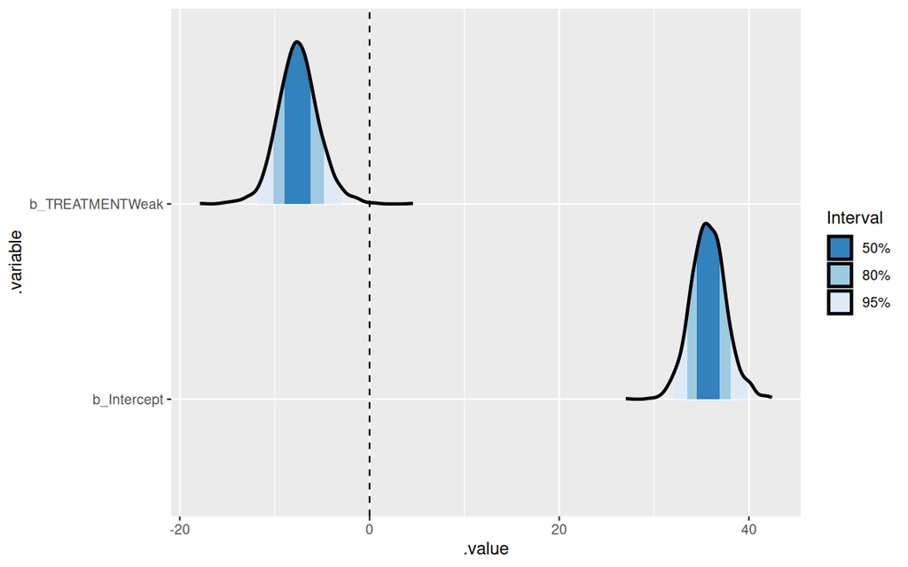

```r
tobacco_brm3 |>
  gather_draws(`b_Intercept.*|b_TREAT.*`, regex = TRUE) |>
  ggplot() +
  geom_vline(xintercept = 0, linetype = "dashed") +
  stat_slab(aes(
    x = .value, y = .variable,
    fill = stat(ggdist::cut_cdf_qi(cdf,
      .width = c(0.5, 0.8, 0.95),
      labels = scales::percent_format()
    ))
  ), color = "black") +
  scale_fill_brewer("Interval", direction = -1, na.translate = FALSE)
```

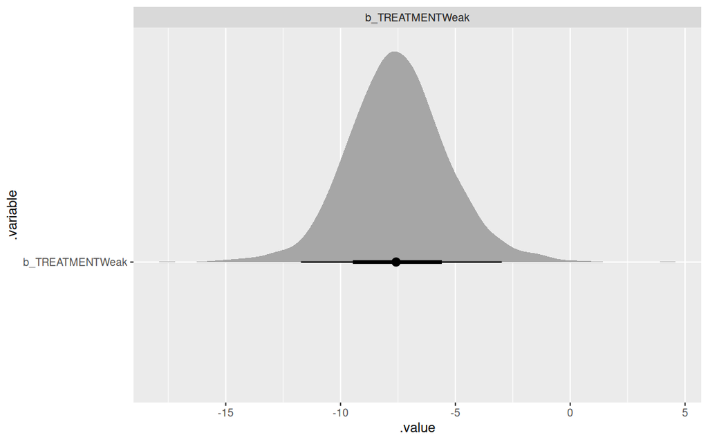

```r
tobacco_brm3 |>
  gather_draws(`.Intercept.*|.*TREAT.*`, regex = TRUE) |>
  ggplot() +
  stat_halfeye(aes(x = .value, y = .variable)) +
  facet_wrap(~.variable, scales = "free")
```

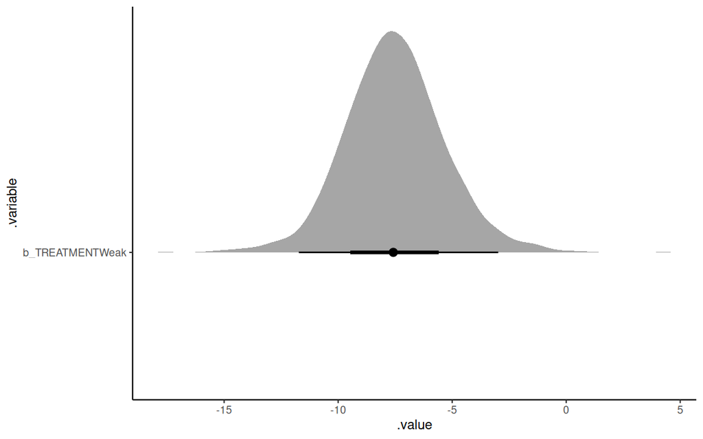

```r
tobacco_brm3 |>
  gather_draws(`.Intercept.*|.*TREAT.*`, regex = TRUE) |>
  ggplot() +
  stat_halfeye(aes(x = .value, y = .variable)) +
  theme_classic()
```

**bayesplot**

```
'pars' not specified. Showing first 10 parameters by default.
```

```
ci_level: 0.8 (80% intervals)
```

```
outer_level: 0.95 (95% intervals)
```

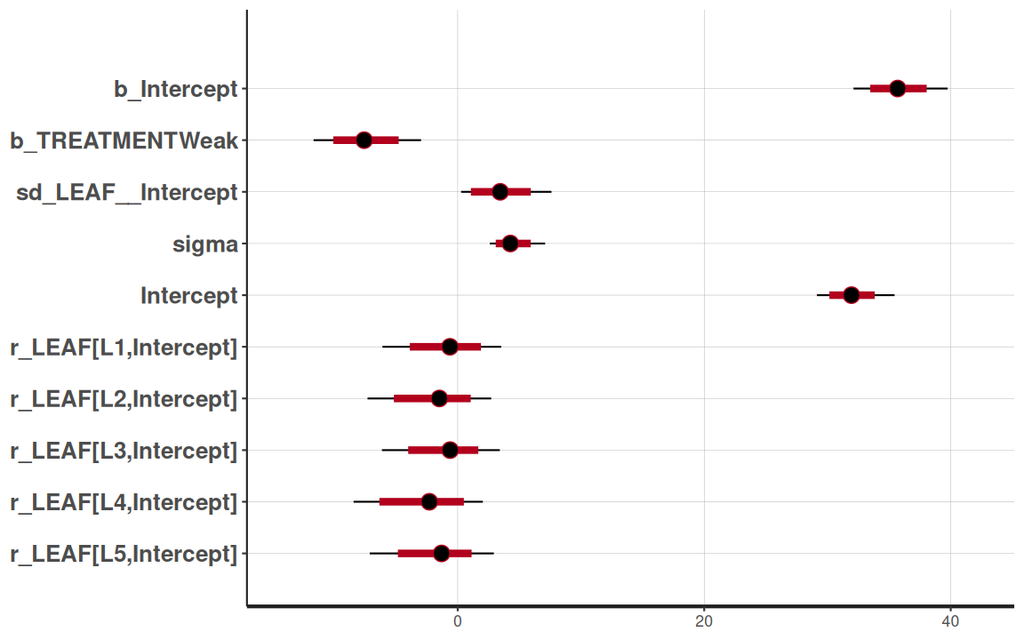

```r
tobacco_brm3$fit |> plot(type = "intervals")
```

**half-eye (ggdist)**

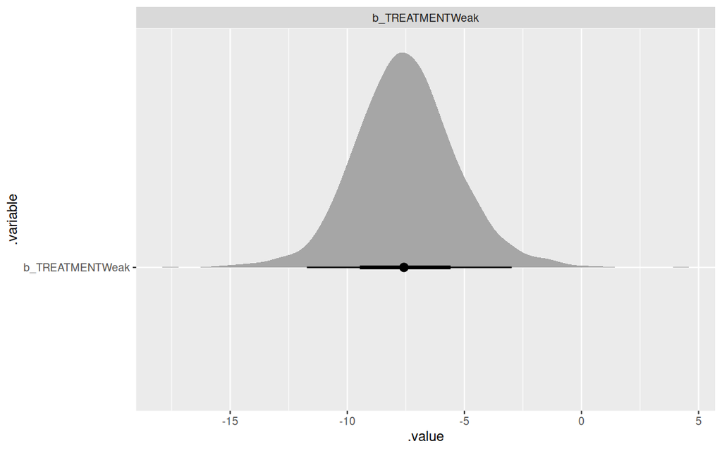

```r
tobacco_brm3 |>
  gather_draws(`^b_.*`, regex = TRUE) |>
  filter(.variable != "b_Intercept") |>
  ggplot() +
  stat_halfeye(aes(x = .value, y = .variable)) +
  facet_wrap(~.variable, scales = "free")
```

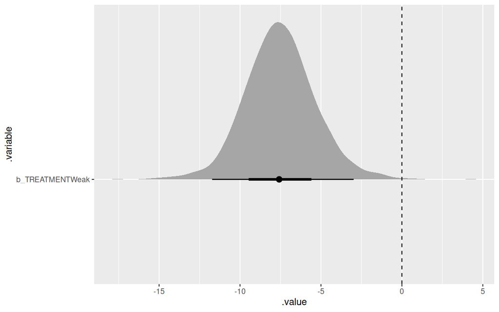

```r
tobacco_brm3 |>
  gather_draws(`^b_.*`, regex = TRUE) |>
  filter(.variable != "b_Intercept") |>
  ggplot() +
  stat_halfeye(aes(x = .value, y = .variable)) +
  geom_vline(xintercept = 0, linetype = "dashed")
```

**density ridges (ggridges)**

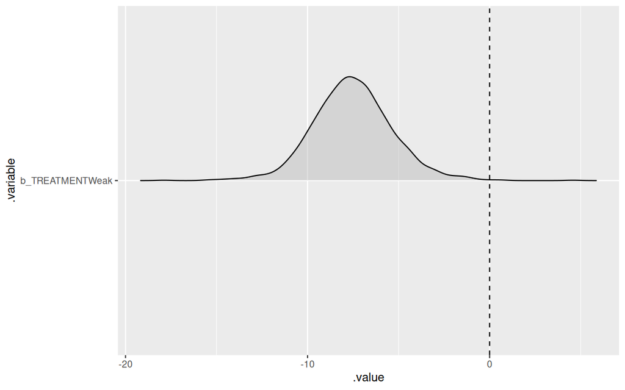

```r
tobacco_brm3 |>
  gather_draws(`^b_.*`, regex = TRUE) |>
  filter(.variable != "b_Intercept") |>
  ggplot() +
  geom_density_ridges(aes(x = .value, y = .variable), alpha = 0.4) +
  geom_vline(xintercept = 0, linetype = "dashed")
```

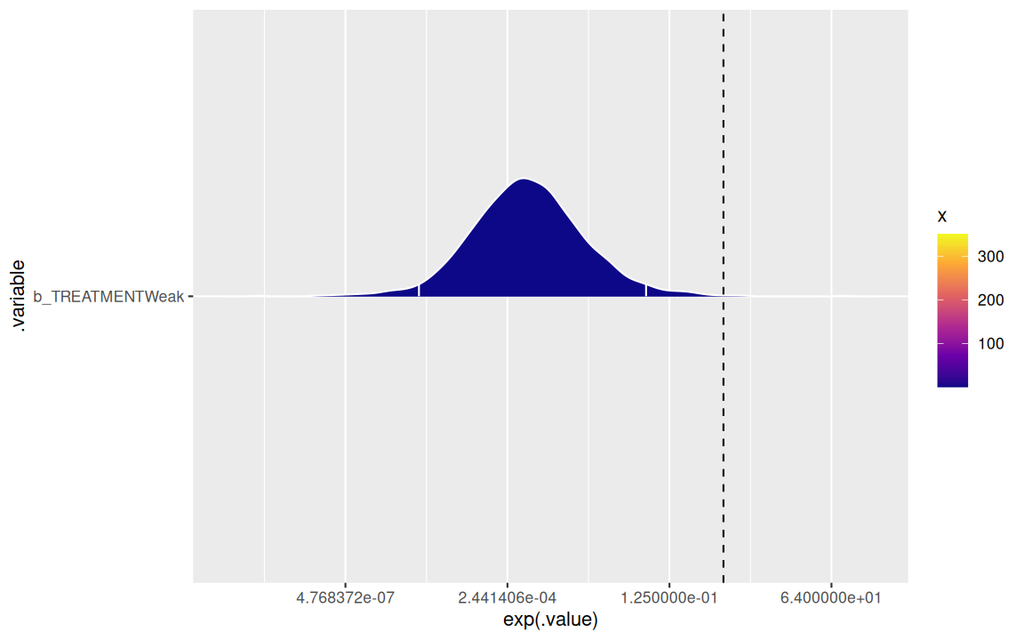

```r
## Or in colour
tobacco_brm3 |>
  gather_draws(`^b_.*`, regex = TRUE) |>
  filter(.variable != "b_Intercept") |>
  ggplot() +
  geom_density_ridges_gradient(
    aes(
      x = exp(.value),
      y = .variable,
      fill = stat(x)
    ),
    alpha = 0.4, colour = "white",
    quantile_lines = TRUE,
    quantiles = c(0.025, 0.975)
  ) +
  geom_vline(xintercept = 1, linetype = "dashed") +
  scale_x_continuous(trans = scales::log2_trans()) +
  scale_fill_viridis_c(option = "C")
```

**tidy_draws**

```r
tobacco_brm3 |> tidy_draws()
```

```
# A tibble: 1,500 × 28
   .chain .iteration .draw b_Intercept b_TREATMENTWeak sd_LEAF__Intercept sigma
    <int>      <int> <int>       <dbl>           <dbl>              <dbl> <dbl>
 1      1          1     1        34.6           -6.10              0.111  4.71
 2      1          2     2        37.2           -9.13              2.79   5.37
 3      1          3     3        34.0           -5.90              6.78   3.88
 4      1          4     4        36.5           -6.76              0.532  6.22
 5      1          5     5        37.9           -8.55              3.65   3.38
 6      1          6     6        36.7           -8.78              7.99   4.31
 7      1          7     7        34.3           -6.86              4.66   4.04
 8      1          8     8        39.1          -13.8               5.01   5.36
 9      1          9     9        33.4           -6.14              5.61   4.03
10      1         10    10        36.9           -8.12              8.05   2.94
# ℹ 1,490 more rows
# ℹ 21 more variables: Intercept <dbl>, `r_LEAF[L1,Intercept]` <dbl>,
#   `r_LEAF[L2,Intercept]` <dbl>, `r_LEAF[L3,Intercept]` <dbl>,
#   `r_LEAF[L4,Intercept]` <dbl>, `r_LEAF[L5,Intercept]` <dbl>,
#   `r_LEAF[L6,Intercept]` <dbl>, `r_LEAF[L7,Intercept]` <dbl>,
#   `r_LEAF[L8,Intercept]` <dbl>, prior_Intercept <dbl>, prior_b <dbl>,
#   prior_sigma <dbl>, prior_sd_LEAF <dbl>, lprior <dbl>, lp__ <dbl>, …
```

**spread_draws**

```r
tobacco_brm3 |> spread_draws(`.*Intercept.*|.*TREAT.*`, regex = TRUE)
```

```
# A tibble: 1,500 × 16
   .chain .iteration .draw b_Intercept b_TREATMENTWeak sd_LEAF__Intercept
    <int>      <int> <int>       <dbl>           <dbl>              <dbl>
 1      1          1     1        34.6           -6.10              0.111
 2      1          2     2        37.2           -9.13              2.79
 3      1          3     3        34.0           -5.90              6.78
 4      1          4     4        36.5           -6.76              0.532
 5      1          5     5        37.9           -8.55              3.65
 6      1          6     6        36.7           -8.78              7.99
 7      1          7     7        34.3           -6.86              4.66
 8      1          8     8        39.1          -13.8               5.01
 9      1          9     9        33.4           -6.14              5.61
10      1         10    10        36.9           -8.12              8.05
# ℹ 1,490 more rows
# ℹ 10 more variables: Intercept <dbl>, `r_LEAF[L1,Intercept]` <dbl>,
#   `r_LEAF[L2,Intercept]` <dbl>, `r_LEAF[L3,Intercept]` <dbl>,
#   `r_LEAF[L4,Intercept]` <dbl>, `r_LEAF[L5,Intercept]` <dbl>,
#   `r_LEAF[L6,Intercept]` <dbl>, `r_LEAF[L7,Intercept]` <dbl>,
#   `r_LEAF[L8,Intercept]` <dbl>, prior_Intercept <dbl>
```

**posterior_samples**

```r
tobacco_brm3 |>
  posterior_samples() |>
  as_tibble()
```

```
# A tibble: 1,500 × 19
   b_Intercept b_TREATMENTWeak sd_LEAF__Intercept sigma Intercept
         <dbl>           <dbl>              <dbl> <dbl>     <dbl>
 1        34.6           -6.10              0.111  4.71      31.6
 2        37.2           -9.13              2.79   5.37      32.7
 3        34.0           -5.90              6.78   3.88      31.0
 4        36.5           -6.76              0.532  6.22      33.1
 5        37.9           -8.55              3.65   3.38      33.6
 6        36.7           -8.78              7.99   4.31      32.3
 7        34.3           -6.86              4.66   4.04      30.9
 8        39.1          -13.8               5.01   5.36      32.2
 9        33.4           -6.14              5.61   4.03      30.3
10        36.9           -8.12              8.05   2.94      32.8
# ℹ 1,490 more rows
# ℹ 14 more variables: `r_LEAF[L1,Intercept]` <dbl>,
#   `r_LEAF[L2,Intercept]` <dbl>, `r_LEAF[L3,Intercept]` <dbl>,
#   `r_LEAF[L4,Intercept]` <dbl>, `r_LEAF[L5,Intercept]` <dbl>,
#   `r_LEAF[L6,Intercept]` <dbl>, `r_LEAF[L7,Intercept]` <dbl>,
#   `r_LEAF[L8,Intercept]` <dbl>, prior_Intercept <dbl>, prior_b <dbl>,
#   prior_sigma <dbl>, prior_sd_LEAF <dbl>, lprior <dbl>, lp__ <dbl>
```

**\(R^2\)**

```r
tobacco_brm3 |>
  bayes_R2(re.form = NA, summary = FALSE) |>
  median_hdci()
```

```
          y       ymin      ymax .width .point .interval
1 0.3686854 0.09345605 0.5697043   0.95 median      hdci
```

```r
tobacco_brm3 |>
  bayes_R2(re.form = ~ (1 | LEAF), summary = FALSE) |>
  median_hdci()
```

```
          y      ymin     ymax .width .point .interval
1 0.6137915 0.2376727 0.833485   0.95 median      hdci
```

```r
tobacco_brm3 |>
  bayes_R2(re.form = ~ (TREATMENT | LEAF), summary = FALSE) |>
  median_hdci()
```

```
          y       ymin      ymax .width .point .interval
1 0.3686854 0.09345605 0.5697043   0.95 median      hdci
```

**ROPE**

Region of Practical Equivalence

```r
0.1 * sd(tobacco$NUMBER)
```

```
[1] 0.6540458
```

```r
tobacco_brm3 |> rope(range = c(-0.65, 0.65))
```

```
# Proportion of samples inside the ROPE [-0.65, 0.65]:

Parameter     | Inside ROPE
---------------------------
Intercept     |      0.00 %
TREATMENTWeak |      0.00 %
```

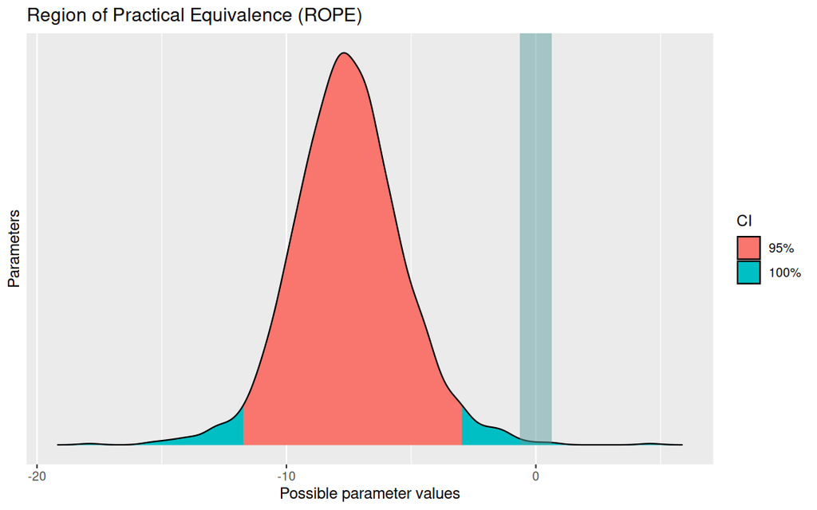

```r
rope(tobacco_brm3, range = c(-0.65, 0.65)) |> plot()
```

```r
## Or based on fractional scale
tobacco_brm3 |>
  emmeans(~TREATMENT) |>
  gather_emmeans_draws() |>
  group_by(.draw) |>
  arrange(desc(TREATMENT)) |>
  summarise(Diff = 100 * (exp(diff(log(.value))) - 1)) |>
  rope(range = c(-10, 10))
```

```
# Proportion of samples inside the ROPE [-10.00, 10.00]:

Parameter | Inside ROPE
-----------------------
.draw     |      0.00 %
Diff      |      0.14 %
```

**Modelsummary**

```r
tobacco_brm3 |> modelsummary(
  statistic = c("conf.low", "conf.high"),
  shape = term ~ statistic,
  exponentiate = TRUE
)
```

|  | (1) Est. | (1) 2.5 % | (1) 97.5 % |
| --- | --- | --- | --- |
| b_Intercept | 3.145628e+15 | 8.882737e+13 | 1.883089e+17 |
| b_TREATMENTWeak | 1.000000e-03 | 0.000000e+00 | 5.100000e-02 |
| sd_LEAF__Intercept | 3.138900e+01 | 1.316000e+00 | 2.009665e+03 |
| sigma | 7.084100e+01 | 1.354400e+01 | 1.215638e+03 |
| Num.Obs. | 16 |  |  |
| R2 | 0.614 |  |  |
| R2 Adj. | 0.435 |  |  |
| R2 Marg. | 0.369 |  |  |
| ICC | 0.9 |  |  |
| ELPD | -50.2 |  |  |
| ELPD s.e. | 2.5 |  |  |
| LOOIC | 100.4 |  |  |
| LOOIC s.e. | 5.1 |  |  |
| WAIC | 98.6 |  |  |
| RMSE | 3.26 |  |  |
| r2.adjusted.marginal | -0.0364657762640077 |  |  |

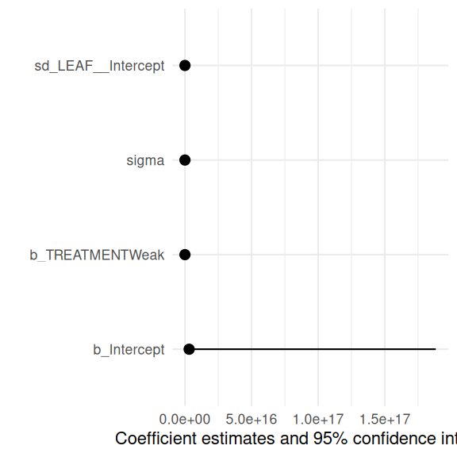

```r
tobacco_brm3 |> modelplot(exponentiate = TRUE)
```

# 9 Further investigations

**brms**

**Via emmeans**

```r
tobacco_brm3 |>
  emmeans(~TREATMENT) |>
  gather_emmeans_draws() |>
  group_by(.draw) |>
  arrange(desc(TREATMENT)) |>
  summarise(Diff = 100 * (exp(diff(log(.value))) - 1)) |>
  summarise_draws(
    median,
    ~ HDInterval::hdi(.x),
    rhat,
    ess_bulk,
    ess_tail
  )
```

```
# A tibble: 1 × 7
  variable median lower upper  rhat ess_bulk ess_tail
  <chr>     <dbl> <dbl> <dbl> <dbl>    <dbl>    <dbl>
1 Diff       26.8  8.68  44.3 1.000    1241.    1452.
```

```r
## Or via gather and pivot
newdata <- tobacco_brm3 |>
  emmeans(~TREATMENT) |>
  gather_emmeans_draws() |>
  pivot_wider(names_from = TREATMENT, values_from = .value) |>
  mutate(
    Eff = Strong - Weak,
    PEff = 100 * Eff / Weak
  )
newdata |> median_hdci(PEff)
```

```
# A tibble: 1 × 6
   PEff .lower .upper .width .point .interval
  <dbl>  <dbl>  <dbl>  <dbl> <chr>  <chr>
1  26.8   8.96   44.7   0.95 median hdci
```

```r
newdata |> summarise(P = mean(PEff > 0))
```

```
# A tibble: 1 × 1
      P
  <dbl>
1 0.998
```

```r
newdata |> summarise(P = mean(PEff > 20))
```

```
# A tibble: 1 × 1
      P
  <dbl>
1 0.803
```

```r
newdata |>
  dplyr::select(-.chain, -.iteration) |>
  hypothesis("PEff>20")
```

```
Hypothesis Tests for class :
       Hypothesis Estimate Est.Error CI.Lower CI.Upper Evid.Ratio Post.Prob
1 (PEff)-(20) > 0     7.09      9.02    -6.88    21.23       4.08       0.8
  Star
1
---
'CI': 90%-CI for one-sided and 95%-CI for two-sided hypotheses.
'*': For one-sided hypotheses, the posterior probability exceeds 95%;
for two-sided hypotheses, the value tested against lies outside the 95%-CI.
Posterior probabilities of point hypotheses assume equal prior probabilities.
```

```r
newdata <- tobacco_brm3 |>
  emmeans(~TREATMENT) |>
  as.data.frame()
head(newdata)
```

```
 TREATMENT   emmean lower.HPD upper.HPD
 Strong    35.68479  32.00457  39.54700
 Weak      28.14294  24.52118  32.06291

Point estimate displayed: median
HPD interval probability: 0.95
```

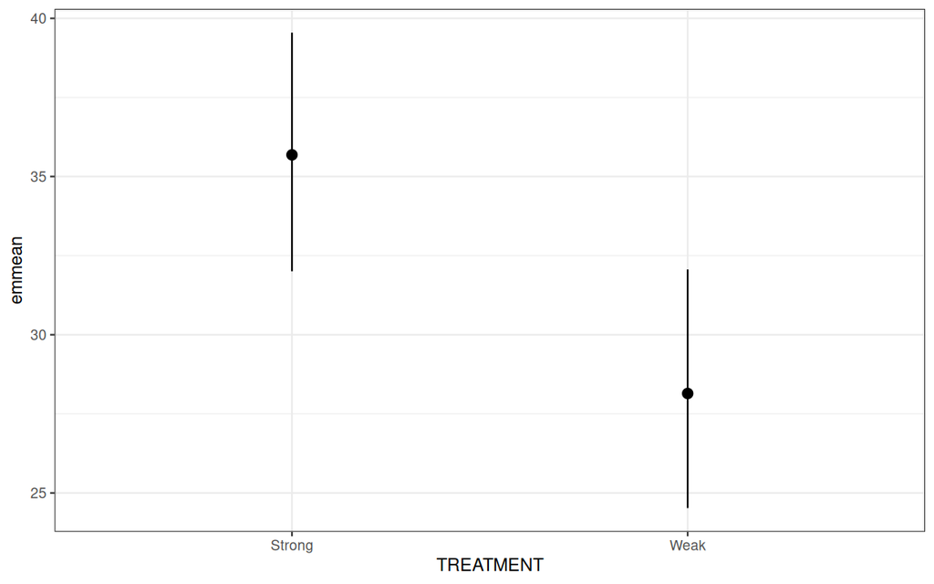

```r
ggplot(newdata, aes(y = emmean, x = TREATMENT)) +
  geom_pointrange(aes(ymin = lower.HPD, ymax = upper.HPD)) +
  theme_bw()
```

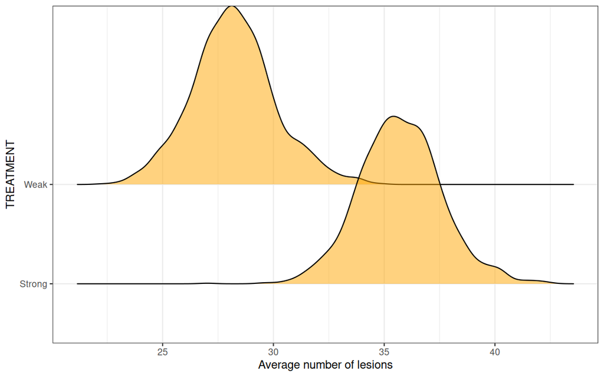

```r
tobacco_brm3 |>
  emmeans(~TREATMENT) |>
  gather_emmeans_draws() |>
  ggplot() +
  geom_density_ridges(aes(x = .value, y = TREATMENT), alpha = 0.5, fill = "orange") +
  scale_x_continuous("Average number of lesions") +
  theme_bw()
```

**Via posterior_epred**

```r
newdat <- tobacco |> tidyr::expand(TREATMENT)
newdata <- tobacco_brm3 |>
  brms::posterior_epred(newdat, re_formula = NA) |>
  as.data.frame() |>
  rename_with(~ as.character(newdat$TREATMENT)) |>
  mutate(
    Eff = Strong - Weak,
    PEff = 100 * Eff / Weak
  )
head(newdata)
```

```
    Strong     Weak      Eff     PEff
1 34.62696 28.52563 6.101326 21.38893
2 37.21866 28.08639 9.132267 32.51492
3 33.97138 28.07141 5.899965 21.01770
4 36.48700 29.72840 6.758597 22.73448
5 37.91998 29.36733 8.552642 29.12298
6 36.73228 27.95512 8.777153 31.39730
```

```r
newdata |> median_hdci(PEff)
```

```
# A tibble: 1 × 6
   PEff .lower .upper .width .point .interval
  <dbl>  <dbl>  <dbl>  <dbl> <chr>  <chr>
1  26.8   8.96   44.7   0.95 median hdci
```

```r
newdata |> summarise(P = mean(PEff > 0))
```

```
      P
1 0.998
```

```r
newdata |> summarise(P = mean(PEff > 20))
```

```
          P
1 0.8033333
```

**Via emmeans and pairs**

```r
newdata <- tobacco_brm3 |>
  emmeans(~TREATMENT) |>
  pairs() |>
  gather_emmeans_draws()
newdata |> median_hdci()
```

```
# A tibble: 1 × 7
  contrast      .value .lower .upper .width .point .interval
  <chr>          <dbl>  <dbl>  <dbl>  <dbl> <chr>  <chr>
1 Strong - Weak   7.58   2.86   11.5   0.95 median hdci
```

```r
## OR on percentage scale
newdata <- tobacco_brm3 |>
  emmeans(~TREATMENT) |>
  regrid(trans = "log") |>
  pairs() |>
  regrid() |>
  gather_emmeans_draws() |>
  mutate(.value = (.value - 1) * 100)
newdata |> median_hdci()
```

```
# A tibble: 1 × 7
  contrast    .value .lower .upper .width .point .interval
  <chr>        <dbl>  <dbl>  <dbl>  <dbl> <chr>  <chr>
1 Strong/Weak   26.8   8.96   44.7   0.95 median hdci
```

```r
newdata |> summarise(P = mean(.value > 0))
```

```
# A tibble: 1 × 2
  contrast        P
  <chr>       <dbl>
1 Strong/Weak 0.998
```

```r
newdata |> summarise(P = mean(.value > 20))
```

```
# A tibble: 1 × 2
  contrast        P
  <chr>       <dbl>
1 Strong/Weak 0.803
```

# 10 References